# Segundo Dia - Importando e Simulando Dados

Pedro Cavalcante

20 de fevereiro de 2019

Agora que cobrimos a sintaxe básica e sabemos conversar com o R, podemos realmente *fazer* coisas. Hoje o foco será em obter dados. Vamos aprender a importar dados de fontes variadas, baixar da internet e cobrir alguns pacotes que baixam dados estruturados de fontes como o Sistema Gerador de Séries do Banco Central do Brasil, Datasus e o Sidra do IBGE. Depois vamos aprender a gerar dados que seguem distribuições probabilísticas e estimar distribuições com dados reais.

# Importando dados

Antes de prosseguirmos é importante garantir que todas as bases de exemplos estejam baixadas e juntas numa pasta só para evitar confusões e facilitar nosso trabalho. Mais ainda, é bom garantir que essa pasta seja a pasta de trabalho com a função `setwd()`. Para descobrir a pasta de trabalho atual e/ou verificar se está tudo certo, basta rodar `getwd()`.

A maior parte dos formatos de dados é coberto pelo pacote `readr`, então tenha-o instalado em sua máquina e carregado antes de prosseguir.

## Dados Delimitados e NAs

Dados delimitados são relativamente comuns. Arquivos assim contém entradas separadas por caracteres específicos. É comum que esses caracteres sejam um espaço, uma vírgula ou um ponto-e-vírgula.

É também comum que algumas observações não estejam completas, esse tipo de entrada vazia é chamado de NA pelo R. Como muitas organizações usam códigos específicos para entradas vazias - como por exemplo 999999999999 pelo IBGE na Pesquisa Nacional de Amostra Domiciliar - vamos também aprender como fazer o R ler essas entradas como faltantes.

A função `readr::read_delim` lê esse tipo de dado, basta dizermos no argumento `delim =` qual caractere é o delimitador. Lembre-se sempre de explorar o arquivo após a leitura para verificar se está tudo em ordem. Para isso é comum usar a função `head()`.

```r
library(readr)
alturas = read_delim("alturas.txt",
                     delim = " ")
head(alturas)
```

```
## # A tibble: 6 x 3
##    sexo idade altura
##   <dbl> <dbl>  <dbl>
## 1     1    19    999
## 2     0    20    172
## 3     1    21    182
## 4     1    22    180
## 5     1    22    181
## 6     1   999    175
```

Observe que o R leu duas pessoas com altura 999cm e idade 999 anos. Isso certamente é um código para dado faltante, então precisamos reler o arquivo, agora levando isso em conta.

```r
library(readr)
alturas = read_delim("alturas.txt",
                     delim = " ",
                     na = "999")
head(alturas)
```

```
## # A tibble: 6 x 3
##    sexo idade altura
##   <dbl> <dbl>  <dbl>
## 1     1    19     NA
## 2     0    20    172
## 3     1    21    182
## 4     1    22    180
## 5     1    22    181
## 6     1    NA    175
```

Agora sim temos uma leitura limpa dos dados.

## Dados de Stata (.dta), Separados por Vírgula (.csv) e de Excel (.xlsx)

O processo é muito similar ao de dados delimitados. O arquivo `ministerios.xlsx` contém dados de gastos ministeriais brasileiros e para lê-lo vamos usar o pacote `readxl`. Os arquivos da forma `prouni.xxx` contém dados a nível de curso do ProUni de 2017.

Vale lembrar que cada versão do Stata tem um padrão diferente para arquivos de dados apesar de todos serem da mesma extensão `.dta`. Para especificar a versão, basta usar o argumento `version =` da função `haven::read_dta`. Por padrão, a versão a ser lida é a 14, mas atualmente todas entre a 8 e a 15 são permitidas.

```r
library(readxl) # para dados de Excel
library(haven) # para dados de Stata

ministerios = read_xlsx("ministerios.xlsx")
head(ministerios)
```

```
## # A tibble: 6 x 6
##   `Ano/Mês` Órgão           GND                     Pago `RP Pago`     Soma
##   <chr>     <chr>           <chr>                  <dbl>     <dbl>    <dbl>
## 1 2001/01   CÂMARA DOS DEP~ INVESTIMENTOS        2.02e 3   919592.  9.22e 5
## 2 2001/01   CÂMARA DOS DEP~ OUTRAS DESPESAS C~   5.60e 6  9518239.  1.51e 7
## 3 2001/01   CÂMARA DOS DEP~ PESSOAL E ENCARGO~   7.27e 7  3819687.  7.65e 7
## 4 2001/01   ENCARGOS FINAN~ AMORTIZACAO/REFIN~   1.97e10 72772660.  1.98e10
## 5 2001/01   ENCARGOS FINAN~ INVERSOES FINANCE~   0.          1870.  1.87e 3
## 6 2001/01   ENCARGOS FINAN~ JUROS E ENCARGOS ~   5.97e 9   962842.  5.97e 9
```

```r
prouni = read_dta("prouni.dta")
head(prouni)
```

```
## # A tibble: 6 x 27
##   Bacharelado Licensiatura Tecnologico Integral Noturno Matutino Distancia
##         <dbl>        <dbl>       <dbl>    <dbl>   <dbl>    <dbl>     <dbl>
## 1           1            0           0        1       0        0         0
## 2           1            0           0        0       1        0         0
## 3           1            0           0        1       0        0         0
## 4           1            0           0        0       1        0         0
## 5           1            0           0        1       0        0         0
## 6           1            0           0        1       0        0         0
## # ... with 20 more variables: Vespertino <dbl>, mensalidade <dbl>,
## #   bolsa_integral_cotas <dbl>, bolsa_integral_ampla <dbl>,
## #   bolsa_parcial_cotas <dbl>, bolsa_parcial_ampla <dbl>,
## #   total_bolsas <dbl>, curso_id <dbl>, Medicina <dbl>,
## #   cidade_busca <chr>, uf_busca <chr>, cidade_filtro <chr>,
## #   universidade_nome <chr>, campus_nome <chr>, campus_id <dbl>,
## #   nome <chr>, nota_integral_ampla <dbl>, nota_integral_cotas <dbl>,
## #   nota_parcial_ampla <dbl>, nota_parcial_cotas <dbl>
```

```r
prouni = read_csv2("prouni.csv")
```

```
## Using ',' as decimal and '.' as grouping mark. Use read_delim() for more control.
```

```r
head(prouni)
```

```
## # A tibble: 6 x 27
##   Bacharelado Licensiatura Tecnologico Integral Noturno Matutino Distancia
##         <dbl>        <dbl>       <dbl>    <dbl>   <dbl>    <dbl>     <dbl>
## 1           1            0           0        1       0        0         0
## 2           1            0           0        0       1        0         0
## 3           1            0           0        1       0        0         0
## 4           1            0           0        0       1        0         0
## 5           1            0           0        1       0        0         0
## 6           1            0           0        1       0        0         0
## # ... with 20 more variables: Vespertino <dbl>, mensalidade <dbl>,
## #   bolsa_integral_cotas <dbl>, bolsa_integral_ampla <dbl>,
## #   bolsa_parcial_cotas <dbl>, bolsa_parcial_ampla <dbl>,
## #   total_bolsas <dbl>, curso_id <dbl>, Medicina <dbl>,
## #   cidade_busca <chr>, uf_busca <chr>, cidade_filtro <chr>,
## #   universidade_nome <chr>, campus_nome <chr>, campus_id <dbl>,
## #   nome <chr>, nota_integral_ampla <dbl>, nota_integral_cotas <dbl>,
## #   nota_parcial_ampla <dbl>, nota_parcial_cotas <dbl>
```

## Formatos específicos do R

A linguagem R tem duas extensões de dados, `.Rdata` e `.Rds`. Ambas são muito úteis porque geram arquivos bem mais leves para um mesmo volume de dados que vários outros formatos populares. `.Rdata` serve para armazenar vários objetos de R - como por exemplo todo o seu ambiente de trabalho - e `.Rds` para um único objeto. Usamos as funções `readRDS()` para ler arquivos dessa extensão e `writeRDS()` para salvar arquivos.

```r
prouni = readRDS("prouni.Rds")
head(prouni)
```

```
## # A tibble: 6 x 27
##   Bacharelado Licensiatura Tecnologico Integral Noturno Matutino Distancia
##         <dbl>        <dbl>       <dbl>    <dbl>   <dbl>    <dbl>     <dbl>
## 1           1            0           0        1       0        0         0
## 2           1            0           0        0       1        0         0
## 3           1            0           0        1       0        0         0
## 4           1            0           0        0       1        0         0
## 5           1            0           0        1       0        0         0
## 6           1            0           0        1       0        0         0
## # ... with 20 more variables: Vespertino <dbl>, mensalidade <dbl>,
## #   bolsa_integral_cotas <dbl>, bolsa_integral_ampla <dbl>,
## #   bolsa_parcial_cotas <dbl>, bolsa_parcial_ampla <dbl>,
## #   total_bolsas <dbl>, curso_id <dbl>, Medicina <dbl>,
## #   cidade_busca <chr>, uf_busca <chr>, cidade_filtro <chr>,
## #   universidade_nome <chr>, campus_nome <chr>, campus_id <dbl>,
## #   nome <chr>, nota_integral_ampla <dbl>, nota_integral_cotas <dbl>,
## #   nota_parcial_ampla <dbl>, nota_parcial_cotas <dbl>
```

## Dados da Internet

### De links Diretos

Uma ferramenta muito boa em R são arquivos temporários. Eles podem ser usados para diversos fins e baixar arquivos diretamente de links dados é um dos mais interessantes. Esse método envolve certa “malícia” de localizar um link correto de download. Não basta propriamento informar a URL de uma página que contenha o link de download do arquivo, precisamos informar o link em si.

Depois de localizado o link para o download do arquivo, o procedimento que normalmente funciona é clicar com o botão direito e depois em “Copiar o Endereço do Link”. Esse endereço é o que usaremos.

[figure not shown]

“View Raw” no Github

[figure not shown]

Copiando o endereço do link de uma página da AER

O procedimento é razoavelmente simples. Primeiro definimos um arquivo temporário com a função `tempfile()`, depois baixamos o arquivo usando a função `download.file()` - cuidado ao alterar o parâmetro `mode=`, ele é um tanto quanto imprevisível - e depois lemos com a função apropriada o arquivo baixado. Como estamos baixando um arquivo em extensão `.rds`, devemos usar `readRDS()`.

```r
link = "https://github.com/danmrc/azul/blob/master/content/post/cox_rais/acre_rais_2017.Rds?raw=true"

temporario = tempfile()
download.file(link, destfile = temporario, mode = "wb")

RAIS_acre = readRDS(temporario)
head(RAIS_acre)
```

```
## # A tibble: 6 x 54
##   `Motivo Desliga~ `CBO Ocupação 2~ `CNAE 2.0 Class~ `CNAE 95 Classe`
##              <int>            <int> <chr>            <chr>
## 1               11           992225 42138            45225
## 2               11           517420 43215            45411
## 3               11           717020 43215            45411
## 4               11           621005 01512            01414
## 5               11           715505 41204            45217
## 6               11           715210 41204            45217
## # ... with 50 more variables: `Vínculo Ativo 31/12` <int>, `Faixa Remun
## #   Dezem (SM)` <chr>, `Faixa Remun Média (SM)` <chr>, `Faixa Tempo
## #   Emprego` <chr>, horas <int>, Idade <int>, `Ind CEI Vinculado` <int>,
## #   `Ind Simples` <int>, `Mês Admissão` <chr>, `Mês Desligamento` <chr>,
## #   `Mun Trab` <chr>, Município <int>, `Natureza Jurídica` <int>, `Ind
## #   Portador Defic` <int>, `Qtd Dias Afastamento` <int>, `Vl Remun
## #   Dezembro Nom` <chr>, `Vl Remun Dezembro (SM)` <chr>, `Vl Remun Média
## #   (SM)` <chr>, `CNAE 2.0 Subclasse` <chr>, duracao <chr>, `Tipo
## #   Admissão` <chr>, `Tipo Estab_1` <chr>, `Tipo Defic` <chr>, `Tipo
## #   Vínculo` <int>, `Ano Chegada Brasil` <chr>, `Ind Trab Parcial` <int>,
## #   `Ind Trab Intermitente` <int>, aposentadoria <dbl>, morte <dbl>,
## #   justacausa <dbl>, outrosmotivos_termino <dbl>, demissao <dbl>,
## #   gringo <dbl>, branco <dbl>, negro <dbl>, outra_etnia <dbl>,
## #   etnia <chr>, homem <dbl>, sexo <chr>, CNPJ <dbl>,
## #   ensino_superior <dbl>, firma_grande <dbl>, industria <dbl>,
## #   servicos <dbl>, agricultura <dbl>, construcao <dbl>, setor <chr>,
## #   salario <dbl>, tempo_emprego <dbl>, Graduacao <chr>
```

### De Pacotes

Vários pacotes de R trazem funcionalidades para importar dados de maneira mais simples, vamos cobrir alguns aqui.

#### Brazilian Economic Time Series (BETS)

O BETS extrai séries diretamente do SGS/BCB, basta alimentar um código específico da série. A função `BETSsearch()` permite fazer buscas, mas o código também pode ser manualmente localizado no site do SGS: https://www3.bcb.gov.br/sgspub/localizarseries/localizarSeries.do?method=prepararTelaLocalizarSeries.

Como spoiler: o código da série de variação mensal do IPCA é 433. Vamos importar uma série e gerar um gráfico. Não se preocupe se você ainda não sabe fazer gráficos no R. Vamos ver isso no próximo encontro - e aprenderemos a fazer gráficos muito mais bonitos.

```r
library(BETS)
citation("BETS")
```

```
##
##
##   Pedro Costa Ferreira, Talitha Speranza and Jonatha Costa (2018).
##   BETS: Brazilian Economic Time Series. R package version 0.4.9.
##   https://CRAN.R-project.org/package=BETS
##
## A BibTeX entry for LaTeX users is
##
##   @Manual{,
##     title = {BETS: Brazilian Economic Time Series},
##     author = {Pedro {Costa Ferreira} and Talitha Speranza and Jonatha Costa},
##     year = {2018},
##     note = {R package version 0.4.9},
##     url = {https://CRAN.R-project.org/package=BETS},
##   }
```

```r
BETSsearch(description = "ipca")
```

```
##
## BETS-package: Found 51 out of 18706 time series.
```

```
## # A tibble: 51 x 7
##    code  description            unit    periodicity start last_value source
##    <chr> <chr>                  <chr>   <chr>       <chr> <chr>      <chr>
##  1 10764 National Consumer Pri~ Monthl~ M           31/0~ mar/2018   IBGE
##  2 10841 National Consumer Pri~ Monthl~ M           31/0~ mar/2018   BCB-D~
##  3 10842 National Consumer Pri~ Monthl~ M           31/0~ mar/2018   BCB-D~
##  4 10843 National Consumer Pri~ Monthl~ M           31/0~ mar/2018   BCB-D~
##  5 10844 National Consumer Pri~ Monthl~ M           31/0~ mar/2018   BCB-D~
##  6 11426 Broad national consum~ Monthl~ M           31/0~ mar/2018   BCB-D~
##  7 11427 Broad national consum~ Monthl~ M           31/0~ mar/2018   BCB-D~
##  8 11428 Broad national consum~ Monthl~ M           31/0~ mar/2018   BCB-D~
##  9 11752 Real effective exchan~ Index   M           31/0~ mar/2018   BCB-D~
## 10 11753 Real effective exchan~ Index   M           31/0~ mar/2018   BCB-D~
## # ... with 41 more rows
```

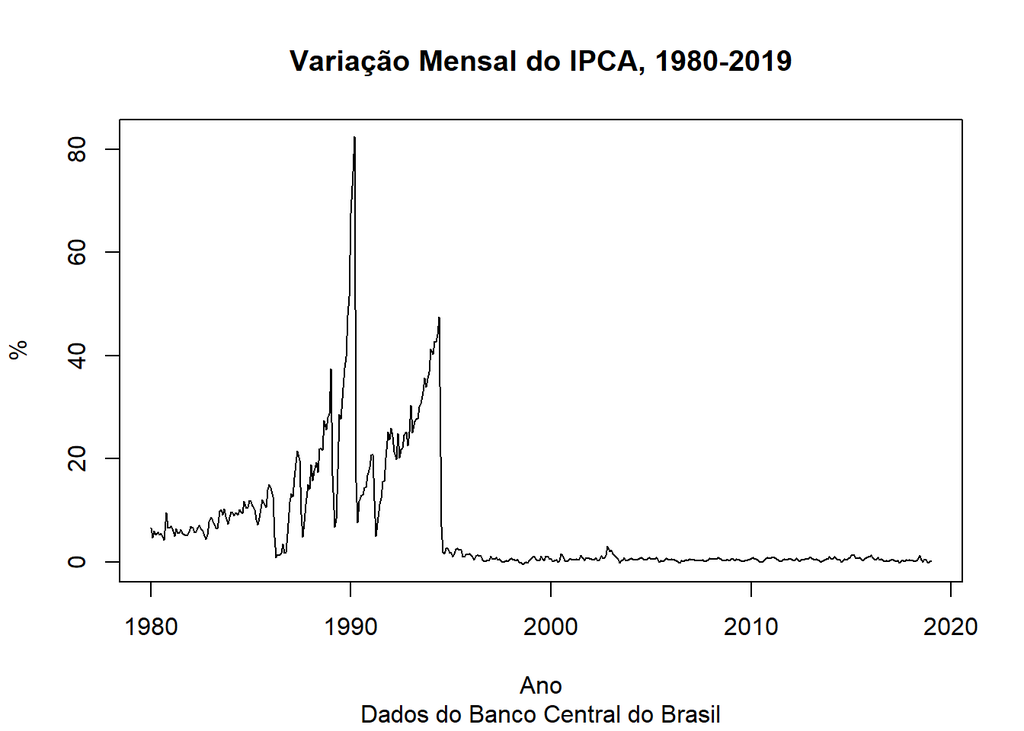

```r
ipca = BETSget(433)
plot(ipca,
     main = "Variação Mensal do IPCA, 1980-2019",
     ylab = "%",
     xlab = "Ano",
     sub = "Dados do Banco Central do Brasil")
```

#### ElectionsBR

O pacote `electionsBR` traz ferramentas para importar dados eleitorais do repositório do TSE. É uma boa ideia olhar a documentação do pacote porque cada tipo de eleição tem uma função própria. Como exemplo vou usar `president_mun_vote()` para baixar dados de eleição presidencial a nível de municípios.

```r
library(electionsBR)
citation("electionsBR")
```

```
##
##
##   Meireles, Fernando; Silva, Denisson; Costa, Beatriz. (2016).
##   electionsBR: R functions to download and clean Brazilian
##   electoral data. URL: http://electionsbr.com/
##
## A BibTeX entry for LaTeX users is
##
##   @Manual{,
##     title = {{electionsBR}: {R} Functions to Download and Clean {B}razilian Electoral Data},
##     author = {Fernando Meireles and Denisson Silva and Beatriz Costa},
##     year = {2016},
##     url = {http://electionsbr.com/},
##   }
```

```r
presidente = president_mun_vote(year = 2010)
head(presidente)
```

```
## # A tibble: 6 x 10
##   ANO_ELEICAO SIGLA_UF CODIGO_MUNICIPIO NOME_MUNICIPIO SIGLA_PARTIDO
##         <int> <chr>               <int> <chr>          <chr>
## 1        2010 AC                   1007 BUJARI         PSDB
## 2        2010 AC                   1007 BUJARI         PT
## 3        2010 AC                   1015 CAPIXABA       PSDB
## 4        2010 AC                   1015 CAPIXABA       PT
## 5        2010 AC                   1023 PORTO ACRE     PSDB
## 6        2010 AC                   1023 PORTO ACRE     PT
## # ... with 5 more variables: NOME_PARTIDO <chr>, NUMERO_PARTIDO <int>,
## #   NOME_COLIGACAO <chr>, COMPOSICAO_LEGENDA <chr>, TOTAL_VOTOS <dbl>
```

#### Outros pacotes

À essa altura espero que você já tenha entendido um pouco o espírito da coisa, então vou deixar uma lista pequena de outros pacotes úteis para importar dados.

- [Quandl](https://www.quandl.com/tools/r) é ótimo para importar dados financeiros.
- [datasus, da Daniela Petruzalek](https://github.com/danicat/datasus). Existem vários pacotes com esse mesmo nome e propósito, mas o da Daniela me pareceu o melhor e mais funcional.
- microdadosBrasil importa e trata varios microdados brasileiros como Censo, PNAD, RAIS e Censo do Ensino Superior.
- [BatchGetSymbols](https://cran.r-project.org/web/packages/BatchGetSymbols/BatchGetSymbols.pdf) ajuda muito a lidar com dados financeiros e importa-los corretamente.
- [quantmod](https://www.quantmod.com/) disponibiliza um ambiente para construção de modelos e cenários, outro muito útil para lidar com dados financeiros.

# Simulando dados

Para simular dados no R basta especificarmos uma distribuição probabilística. O pacote `stats`, parte da Biblioteca Padrão, traz várias funções que cobrem todas as facetas das distribuições mais comuns, como a Normal, Poisson, binomial e exponencial. Distribuições mais exóticas como a Pareto II, Pareto IV, de Maddala e Lognormal Discreta estão disponíveis em pacotes como o `VGAM` e o `extraDistr`. Para uma lista completa dos pacotes disponíveis com distribuições, é só acessar o CRAN TaskView de Distribuições Probabilísticas, disponível em: https://cran.r-project.org/web/views/Distributions.html.

Funções relacionadas à distribuições sempre têm a mesma estrutura de nome: `xfoo`, onde x é uma letra e foo é abreviação de alguma distribuição. As letras são, normalmente, `d`, `p`, `q` e `r`, cada uma com um propósito específico.

- Funções `p` devolvem a probabilidade acumulada de uma entrada. É a Função de Distribuição Acumulada.
- Funções `q` devolvem o quantil de uma probabilidade especificada. É a Função Inversa de Distribuição Acumulada.
- Funções `d` devolvem a densidade da distribuição, a derivada da Função de Distribuição Acumulada.
- Funções `r` (do inglês, *random*) devolvem um valor aleatório que segue a distribuição especificada.

Algumas funções e suas abreviações:

- `norm` para a Normal
- `pois` para a Poisson
- `t` para a T de Student
- `exp` para a exponencial
- `gamma` para a Gamma
- `f` para a F de Fisher-Snedecor
- `unif` para a Uniforme

## Um pequeno aviso sobre geração de dados “aleatórios”

É difícil fielmente gerar dados *aleatórios* porque sempre precisamos de algum processo gerador dos dados por trás. Esse assunto é um tanto quanto complexo, mas vale introduzir uma noção aqui de Semente Aleatória (Random Seed).

Todo gerador pseudoaleatório de números precisa de um número inicial para começar. Chamamos esse número de Semente (Aleatória) ou de Seed. O R tem uma semente padrão, mas para garantir que nossos resultados não mudam entre uma sessão de trabalho e outra, é sempre de bom tom usar a função `set.seed()` para definir uma semente antes de começar a trabalhar e deixa-la em nossos scripts. O número em si não importa, pode ser 1, 123, 1001 ou 6516871651567416871.

Bons geradores pseudoaleatórios de números são pouco sensíveis à escolha da semente, só precisam de um número qualquer. É bom rodar seus modelos com 2 ou 3 sementes diferentes para verificar que seus resultados não estão aparecendo por conta da semente escolhida, mas isso tem como objetivo aliviar a consciência muito mais do que encontrar erros. É realmente difícil que uma semente específica introduza resultados muito peculiares.

Tenha em mente, no entanto, que um mesmo processo pseudoaleatório gera os mesmos dados se tiver a mesma semente. Em alguns momentos isso é interessante, em outros não. Vou dar dois exemplos:

- Imagine que você está rodando alguns modelos de classificação de risco para uma seguradora. É importante garantir consistência sempre, então escolher a *mesma* semente é uma boa prática, dado que você já testou o modelo com algumas sementes diferentes.
- Imagine que você tem um bot de twitter que tweeta aleatoriamente pedaços de letras de um artista, escolhidas ao acaso de um banco de dados com letras desse artista. Para não repetir a mesma escolha sempre, é bom tornar o processo de escolher a semente aleatório. Um bom truque é usar a função `Sys.time()`, que pega data e hora no momento em que é rodada, combinar com a função `as.numeric()` para transforma-la em um número e então dar esse número como semente aleatória.

```r
Sys.time()
```

```
## [1] "2019-03-07 19:56:29 -03"
```

```r
semente = as.numeric(Sys.time())
print(semente)
```

```
## [1] 1551999390
```

```r
set.seed(as.numeric(Sys.time()))

## ou alternativamente

set.seed(semente)
```

É também importante ter em mente quais são os argumentos padrão das funções sendo usadas. A função `rnorm`, por exemplo, tem por padrão média 0 e desvio-padrão unitário - porque essa é a Normal Padrão. Lembre-se de que as funções para simular distribuições no R sempre recebem como argumento o *desvio-padrão*, no argumento `sd=` e não a variância. Já as funções da distribuição Gamma aceitam duas fórmulas diferentes para a densidade da distribuição, então é importante ler a documentação para saber como conseguir a que você quer.

```r
## EXEMPLOS COM DISTRIBUIÇÕES DE PROBABILIDADE

set.seed(1234) # semente definida

pnorm(28, mean = 25, sd = sqrt(32)) # probabilidade acumulada do valor 28 numa distribuição N(25, 32)
```

```
## [1] 0.7020585
```

```r
rnorm(n = 10) # 10 números aleatórios com distribuição de uma normal padrão
```

```
##  [1] -1.2070657  0.2774292  1.0844412 -2.3456977  0.4291247  0.5060559
##  [7] -0.5747400 -0.5466319 -0.5644520 -0.8900378
```

```r
rnorm(15, mean = 2, sd = 2) # 15 números aleatórios com distribuição de uma normal N(2, 4)
```

```
##  [1] 1.04561460 0.00322711 0.44749221 2.12891763 3.91898812 1.77942901
##  [7] 0.97798099 0.17760917 0.32565664 6.83167036 2.26817644 1.01862821
## [13] 1.11890426 2.91917888 0.61255951
```

```r
qnorm(0.3, mean = 25, sd = sqrt(32)) # número com probabilidade acumulada de 30% em uma normal N(25, 32)
```

```
## [1] 22.03354
```

```r
dt(2, df = 10) # valor da densidade de uma t de Student com 10 graus de liberdade no 2
```

```
## [1] 0.06114577
```

```r
punif(0, min = -1, max = 1) # probabilidade acumulada no 0 de uma U(-1, 1)
```

```
## [1] 0.5
```

Podemos testar propriedades de dados para verificar se aderem à distribuições particulares com alguns testes estatísticos. Tome $X \sim N(2, 8)$. Vamos gerar uma amostra com $n = 2000$ que segue a distribuição $X$. Depois, vamos aplicar dois testes de hipótese muito comuns. O primeiro é o de Shapiro-Wilk, serve para testar normalidade e o outro é o de Kolmogorof-Smirnov, que serve para testar se dados de uma amostra aderem a uma distribuição contínua qualquer.

```r
X = rnorm(n = 2000,
          mean = 2,
          sd = sqrt(8))

sd(X) # desvio-padrão dos dados
```

```
## [1] 2.802836
```

```r
var(X) # variância dos dados
```

```
## [1] 7.855889
```

```r
mean(X) # média dos dados
```

```
## [1] 1.986049
```

```r
sample(X, size = 7) # 7 elementos aleatoriamente escolhidos de X
```

```
## [1]  3.6251282 -2.6957925 -0.3690409  1.5793550 -0.6011442  6.8351172
## [7] -3.7130131
```

```r
shapiro.test(X) # teste de Shapiro-Wilk de normalidade de dados
```

```
##
##  Shapiro-Wilk normality test
##
## data:  X
## W = 0.99915, p-value = 0.4939
```

```r
ks.test(X,
        "pnorm",
        mean = 2,
        sd = sqrt(8)) # teste de Kolmogorov-Smirnov de Aderência
```

```
##
##  One-sample Kolmogorov-Smirnov test
##
## data:  X
## D = 0.013611, p-value = 0.8526
## alternative hypothesis: two-sided
```

# Exercícios

- Abra o arquivo `exercicio1.Rds` e teste se ele adere à uma distribuição t de Student com 5, 10 ou 15 graus de liberdade
- Abra o arquivo `exercicio2.Rds` e teste se os dados aderem à uma Normal com média 0 e variância 10.
- Abra o arquivo `exercicio3.dta` e teste se os dados são normais.
- $P(3 < Y < 30)$ dado que $Y \sim \text{Poisson}(8)$
- Gere uma vetor $A \sim F(2, 4)$
- Encontre o número $c$ tal que $P(Z>c) = 0.7$ e $Z \sim Gamma(1, 5)$